# Forecasting Temperature 14/04 - 19/12 2024

# 1 Impor Library

```r
library("forecast")
```

```r
library("graphics")
library("TTR")
library("TSA")
library("aTSA")
library("lmtest")
library("MLmetrics")
library("car")
library("dplyr")
library("MASS")
library("tsibble")
library("tseries")
library("ggplot2")
library("nortest")
```

```r
library("readxl")
library("dplyr")
```

# 2 Import Data

```r
temp <- read_excel("D:/Semester 5/MPDW/Varel.xlsx")
head(temp)
```

```
## # A tibble: 6 × 3
##   date                temp_mean  part
##   <dttm>                  <dbl> <dbl>
## 1 2024-04-14 00:00:00      26.2     3
## 2 2024-04-15 00:00:00      26.5     3
## 3 2024-04-16 00:00:00      26.9     3
## 4 2024-04-17 00:00:00      26.3     3
## 5 2024-04-18 00:00:00      26.4     3
## 6 2024-04-19 00:00:00      26.5     3
```

```r
temp <- dplyr::select(temp, date, temp_mean)
head(temp)
```

```
## # A tibble: 6 × 2
##   date                temp_mean
##   <dttm>                  <dbl>
## 1 2024-04-14 00:00:00      26.2
## 2 2024-04-15 00:00:00      26.5
## 3 2024-04-16 00:00:00      26.9
## 4 2024-04-17 00:00:00      26.3
## 5 2024-04-18 00:00:00      26.4
## 6 2024-04-19 00:00:00      26.5
```

# 3 Eksplorasi Data

```r
View(temp)
str(temp)
```

```
## tibble [250 × 2] (S3: tbl_df/tbl/data.frame)
##  $ date     : POSIXct[1:250], format: "2024-04-14" "2024-04-15" ...
##  $ temp_mean: num [1:250] 26.2 26.5 26.9 26.3 26.4 26.5 26 26.2 27 26.6 ...
```

```r
dim(temp)
```

```
## [1] 250   2
```

```r
colSums(is.na(temp))
```

```
##      date temp_mean
##         0         0
```

Data yang digunakan sudah lengkap, tidak ditemukan missing value pada data.

```r
temp.ts <- ts(temp$temp_mean)
summary(temp.ts)
```

```
##    Min. 1st Qu.  Median    Mean 3rd Qu.    Max.
##   24.20   26.23   26.70   26.76   27.30   29.90
```

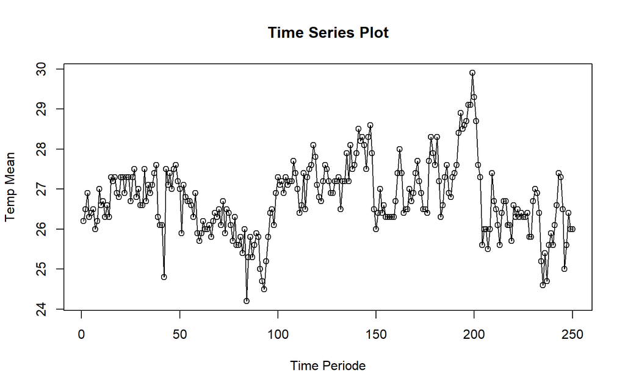

```r
ts.plot(temp.ts, xlab="Time Periode", ylab="Temp Mean", main = "Time Series Plot")
points(temp.ts)
```

Kemungkinan data tidak stasiuoner dalam rataan

# 4 Pembagian Data

```r
n <- nrow(temp)

n_train <- floor(0.8*n)

training_ma <- temp[1:n_train, ]
testing_ma <- temp[(n_train+1):n, ]

train_ma.ts <- ts(training_ma$temp_mean)
test_ma.ts <- ts(testing_ma$temp_mean)
```

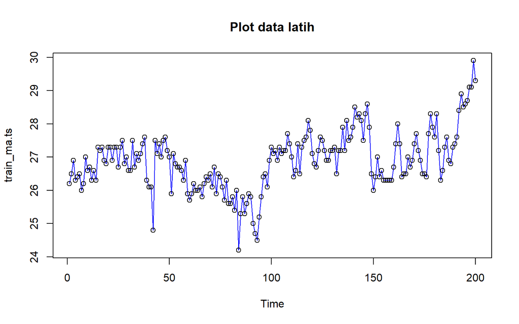

```r
plot(train_ma.ts, col="blue",main="Plot data latih")
points(train_ma.ts)
```

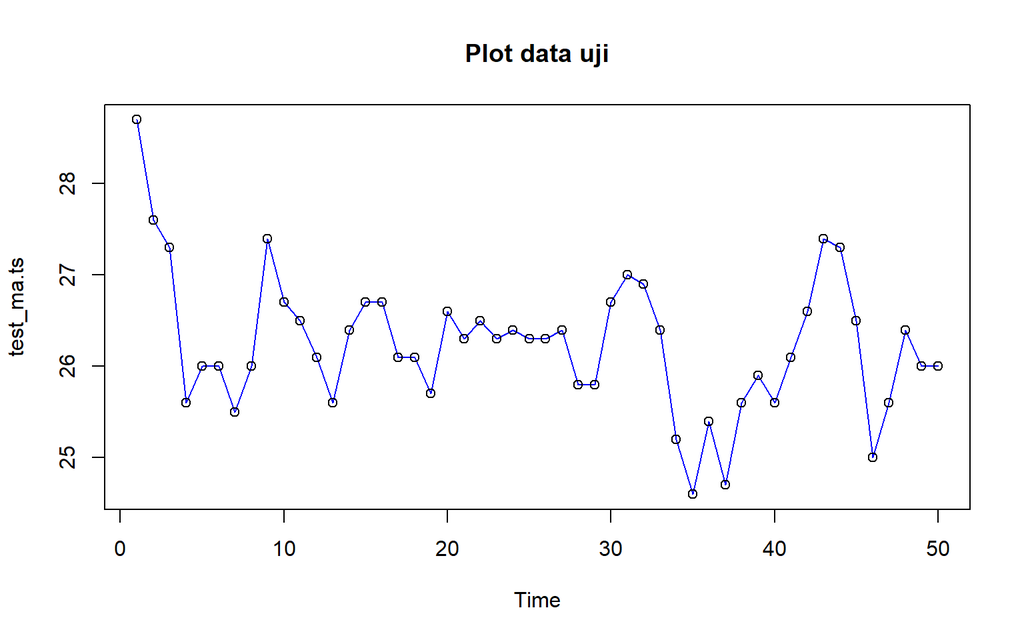

```r
plot(test_ma.ts, col="blue",main="Plot data uji")
points(test_ma.ts)
```

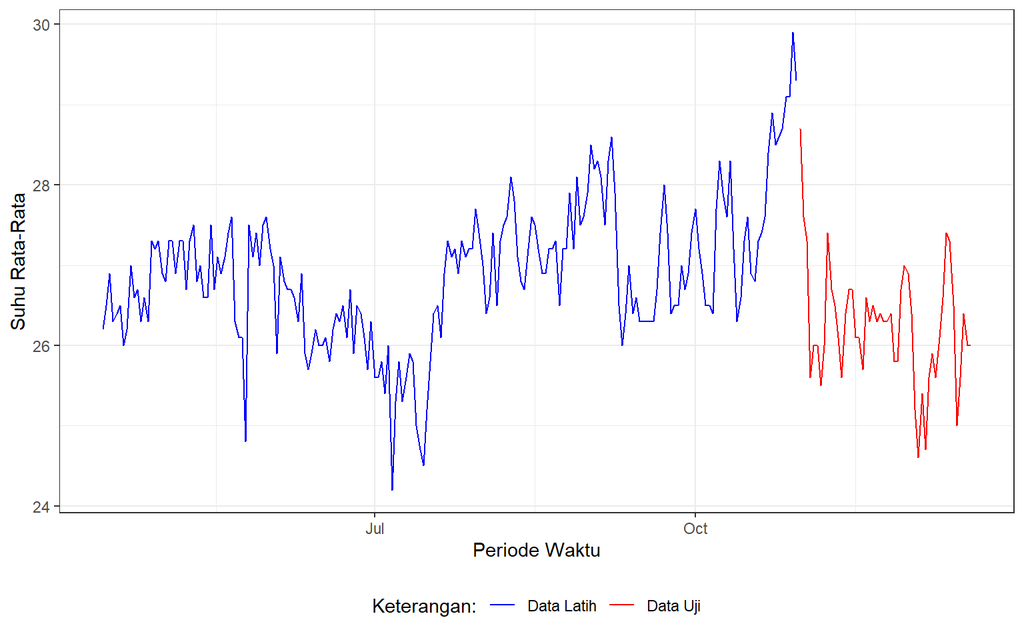

```r
ggplot() +
  geom_line(data = training_ma, aes(x = date, y = temp_mean, col = "Data Latih")) +
  geom_line(data = testing_ma, aes(x = date, y = temp_mean, col = "Data Uji")) +
  labs(x = "Periode Waktu", y = "Suhu Rata-Rata", color = "Legend") +
   scale_colour_manual(name="Keterangan:", breaks = c("Data Latih", "Data Uji"),
                      values = c("blue", "red")) +
  theme_bw() + theme(legend.position = "bottom",
                     plot.caption = element_text(hjust=0.5, size=12))
```

# 5 SINGLE MOVING AVERAGE (SMA)

```r
data.sma<-SMA(train_ma.ts, n=3)
data.sma
```

```
## Time Series:
## Start = 1
## End = 200
## Frequency = 1
##   [1]       NA       NA 26.53333 26.56667 26.53333 26.40000 26.30000 26.23333
##   [9] 26.40000 26.60000 26.76667 26.53333 26.53333 26.40000 26.73333 26.93333
##  [17] 27.26667 27.13333 27.00000 27.00000 27.13333 27.16667 27.16667 27.16667
##  [25] 27.10000 27.10000 27.16667 27.20000 27.10000 26.80000 26.73333 26.90000
##  [33] 26.93333 27.10000 26.90000 27.03333 27.13333 27.36667 27.10000 26.66667
##  [41] 26.16667 25.66667 26.13333 26.46667 27.33333 27.16667 27.30000 27.36667
##  [49] 27.43333 27.26667 26.70000 26.66667 26.60000 26.86667 26.73333 26.66667
##  [57] 26.53333 26.60000 26.36667 26.16667 25.83333 25.93333 26.03333 26.06667
##  [65] 26.03333 25.96667 26.03333 26.13333 26.30000 26.40000 26.30000 26.43333
##  [73] 26.23333 26.36667 26.26667 26.33333 26.06667 26.03333 25.86667 25.83333
##  [81] 25.66667 25.60000 25.73333 25.20000 25.16667 25.10000 25.46667 25.56667
##  [89] 25.60000 25.76667 25.56667 25.16667 24.73333 24.80000 25.16667 25.80000
##  [97] 26.23333 26.33333 26.50000 26.76667 27.10000 27.20000 27.06667 27.13333
## [105] 27.10000 27.20000 27.16667 27.36667 27.43333 27.36667 26.93333 26.66667
## [113] 26.80000 26.83333 27.06667 27.10000 27.46667 27.73333 27.83333 27.66667
## [121] 27.23333 26.86667 26.90000 27.16667 27.43333 27.43333 27.20000 27.00000
## [129] 27.00000 27.10000 27.23333 27.00000 27.00000 26.96667 27.43333 27.43333
## [137] 27.73333 27.60000 27.73333 27.66667 28.00000 28.20000 28.33333 28.20000
## [145] 27.96667 27.96667 28.13333 28.26667 27.66667 26.80000 26.30000 26.46667
## [153] 26.60000 26.66667 26.43333 26.40000 26.30000 26.30000 26.30000 26.43333
## [161] 26.80000 27.36667 27.60000 27.26667 26.76667 26.46667 26.66667 26.73333
## [169] 26.86667 27.00000 27.33333 27.43333 27.26667 26.86667 26.63333 26.46667
## [177] 26.86667 27.46667 27.96667 27.93333 27.93333 27.70000 27.26667 26.70000
## [185] 26.73333 27.16667 27.26667 27.10000 27.00000 27.16667 27.43333 27.80000
## [193] 28.30000 28.60000 28.66667 28.60000 28.80000 28.96667 29.36667 29.43333
```

```r
data.ramal<-c(NA,data.sma)
head(data.ramal) #forecast 1 periode ke depan
```

```
## [1]       NA       NA       NA 26.53333 26.56667 26.53333
```

```r
data.gab<-cbind(
  aktual=c(temp.ts),
  pemulusan=c(data.sma,rep(NA,50)),
  ramalan=c(data.ramal,rep(data.ramal[length(data.ramal)],49)))

head(data.gab)
```

```
##      aktual pemulusan  ramalan
## [1,]   26.2        NA       NA
## [2,]   26.5        NA       NA
## [3,]   26.9  26.53333       NA
## [4,]   26.3  26.56667 26.53333
## [5,]   26.4  26.53333 26.56667
## [6,]   26.5  26.40000 26.53333
```

## 5.1 Visualisasi Data

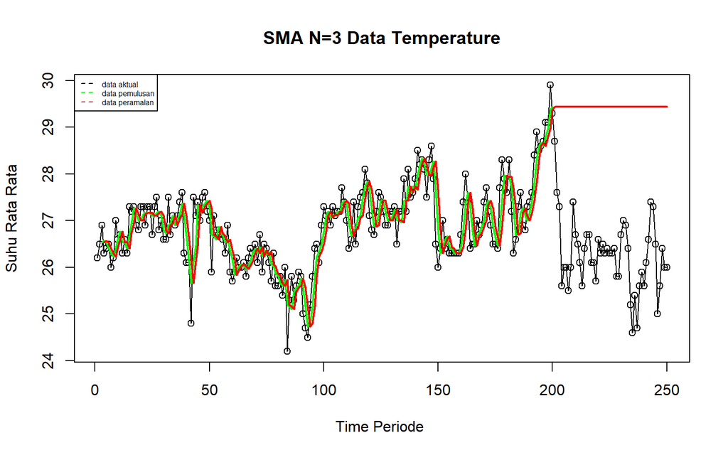

```r
ts.plot(temp.ts, xlab="Time Periode ", ylab="Suhu Rata Rata", main= "SMA N=3 Data Temperature")
points(temp.ts)
lines(data.gab[,2],col="green",lwd=2)
lines(data.gab[,3],col="red",lwd=2)
legend("topleft",c("data aktual","data pemulusan","data peramalan"), lty=8, col=c("black","green","red"), cex=0.5)
```

## 5.2 Akurasi Data Latih

```r
error_train.sma = train_ma.ts-data.ramal[1:length(train_ma.ts)]

SSE_train.sma = sum(error_train.sma[4:length(train_ma.ts)]^2)
MSE_train.sma = mean(error_train.sma[4:length(train_ma.ts)]^2)
MAPE_train.sma = mean(abs((error_train.sma[4:length(train_ma.ts)]/train_ma.ts[4:length(train_ma.ts)])*100))

akurasi_train.sma <- matrix(c(SSE_train.sma, MSE_train.sma, MAPE_train.sma))
row.names(akurasi_train.sma)<- c("SSE", "MSE", "MAPE")
colnames(akurasi_train.sma) <- c("Akurasi m = 3")
akurasi_train.sma
```

```
##      Akurasi m = 3
## SSE     65.1322222
## MSE      0.3306204
## MAPE     1.6514553
```

## 5.3 Akurasi Data Uji

```r
error_test.sma = test_ma.ts-data.gab[201:250,3]

SSE_test.sma = sum(error_test.sma^2)
MSE_test.sma = mean(error_test.sma^2)
MAPE_test.sma = mean(abs((error_test.sma/test_ma.ts*100)))

akurasi_test.sma <- matrix(c(SSE_test.sma, MSE_test.sma, MAPE_test.sma))
row.names(akurasi_test.sma)<- c("SSE", "MSE", "MAPE")
colnames(akurasi_test.sma) <- c("Akurasi m = 3")
akurasi_test.sma
```

```
##      Akurasi m = 3
## SSE      535.39889
## MSE       10.70798
## MAPE      12.23250
```

# 6 DOUBLE MOVING AVERAGE (DMA)

```r
dma <- SMA(data.sma, n = 3)
At <- 2*data.sma - dma
Bt <- 2/(3-1)*(data.sma - dma)
data.dma<- At+Bt
data.ramal2<- c(NA, data.dma)

t = 1:50
f = c()

for (i in t) {
  f[i] = At[length(At)] + Bt[length(Bt)]*(i)
}

data.gab2 <- cbind(aktual = c(temp.ts),
                   pemulusan1 = c(data.sma,rep(NA,50)),
                   pemulusan2 = c(dma, rep(NA,50)),
                   At = c(At, rep(NA,50)),
                   Bt = c(Bt,rep(NA,50)),
                   ramalan = c(data.ramal2, f[-1]))
head(data.gab2)
```

```
##      aktual pemulusan1 pemulusan2       At          Bt  ramalan
## [1,]   26.2         NA         NA       NA          NA       NA
## [2,]   26.5         NA         NA       NA          NA       NA
## [3,]   26.9   26.53333         NA       NA          NA       NA
## [4,]   26.3   26.56667         NA       NA          NA       NA
## [5,]   26.4   26.53333   26.54444 26.52222 -0.01111111       NA
## [6,]   26.5   26.40000   26.50000 26.30000 -0.10000000 26.51111
```

## 6.1 Visualisasi Data

[figure not shown]

```r
ts.plot(temp.ts, xlab="Time Period ", ylab="Temperature Mean", main= "DMA N=5 Data Sales")
points(temp.ts)
lines(data.gab2[,3],col="green",lwd=2)
lines(data.gab2[,6],col="red",lwd=2)
legend("topleft",c("data aktual","data pemulusan","data peramalan"), lty=8, col=c("black","green","red"), cex=0.8)
```

## 6.2 Akurasi Data Latih

```r
error_train.dma = train_ma.ts-data.ramal2[1:length(train_ma.ts)]

SSE_train.dma = sum(error_train.dma[6:length(train_ma.ts)]^2)
MSE_train.dma = mean(error_train.dma[6:length(train_ma.ts)]^2)
MAPE_train.dma = mean(abs((error_train.dma[6:length(train_ma.ts)]/train_ma.ts[6:length(train_ma.ts)])*100))

akurasi_train.dma <- matrix(c(SSE_train.dma, MSE_train.dma, MAPE_train.dma))
row.names(akurasi_train.dma)<- c("SSE", "MSE", "MAPE")
colnames(akurasi_train.dma) <- c("Akurasi m = 3")
akurasi_train.dma
```

```
##      Akurasi m = 3
## SSE     96.0307407
## MSE      0.4924653
## MAPE     1.9841049
```

## 6.3 Akurasi Data Uji

```r
error_test.dma = test_ma.ts-data.gab2[201:250,6]
SSE_test.dma = sum(error_test.dma^2)
MSE_test.dma = mean(error_test.dma^2)
MAPE_test.dma = mean(abs((error_test.dma/test_ma.ts*100)))

akurasi_test.dma <- matrix(c(SSE_test.dma, MSE_test.dma, MAPE_test.dma))
row.names(akurasi_test.dma)<- c("SSE", "MSE", "MAPE")
colnames(akurasi_test.dma) <- c("Akurasi m = 5")
akurasi_test.dma
```

```
##      Akurasi m = 5
## SSE     3534.69963
## MSE       70.69399
## MAPE      30.28052
```

# 7 SINGLE EXPONENTIAL SMOOTHING (SES)

## 7.1 Fungsi SES

### 7.1.1 $\alpha=0.2$

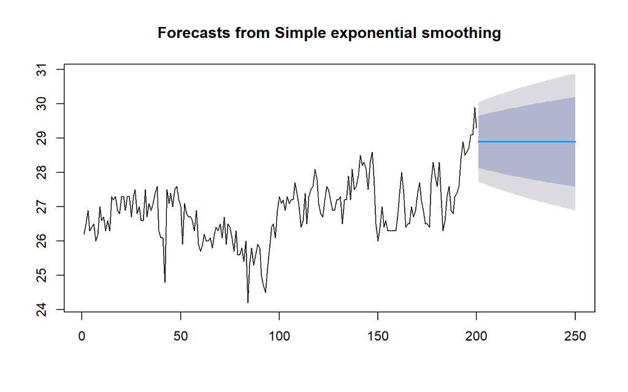

```r
ses.1 <- ses(train_ma.ts, h = 50, alpha = 0.2)
plot(ses.1)
```

```r
ses.1
```

```
##     Point Forecast    Lo 80    Hi 80    Lo 95    Hi 95
## 201       28.89443 28.13550 29.65336 27.73375 30.05511
## 202       28.89443 28.12047 29.66839 27.71076 30.07810
## 203       28.89443 28.10573 29.68313 27.68822 30.10065
## 204       28.89443 28.09126 29.69760 27.66608 30.12278
## 205       28.89443 28.07704 29.71182 27.64434 30.14452
## 206       28.89443 28.06307 29.72579 27.62297 30.16589
## 207       28.89443 28.04932 29.73954 27.60195 30.18691
## 208       28.89443 28.03580 29.75306 27.58127 30.20759
## 209       28.89443 28.02249 29.76637 27.56091 30.22795
## 210       28.89443 28.00938 29.77949 27.54086 30.24801
## 211       28.89443 27.99645 29.79241 27.52109 30.26777
## 212       28.89443 27.98372 29.80514 27.50161 30.28725
## 213       28.89443 27.97115 29.81771 27.48240 30.30646
## 214       28.89443 27.95876 29.83010 27.46345 30.32541
```

[output cut: 36 more lines]

### 7.1.2 $\alpha=0.7$

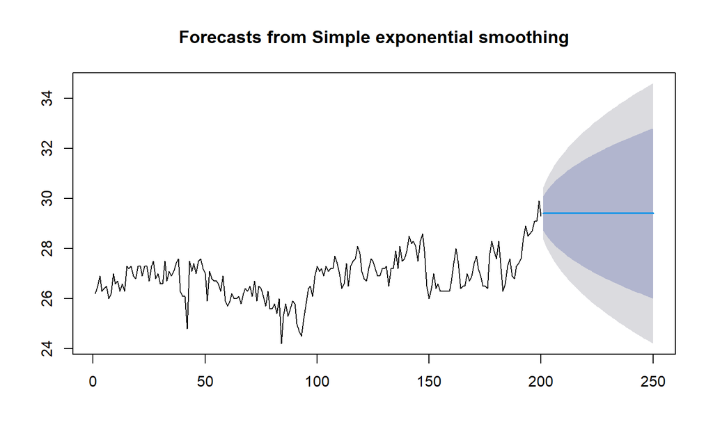

```r
ses.2<- ses(train_ma.ts, h = 50, alpha = 0.7)
plot(ses.2)
```

```r
ses.2
```

```
##     Point Forecast    Lo 80    Hi 80    Lo 95    Hi 95
## 201       29.40448 28.72504 30.08392 28.36537 30.44360
## 202       29.40448 28.57512 30.23384 28.13608 30.67288
## 203       29.40448 28.44842 30.36054 27.94232 30.86665
## 204       29.40448 28.33666 30.47231 27.77138 31.03758
## 205       29.40448 28.23553 30.57343 27.61672 31.19224
## 206       29.40448 28.14248 30.66649 27.47441 31.33455
## 207       29.40448 28.05583 30.75313 27.34190 31.46706
## 208       29.40448 27.97442 30.83454 27.21740 31.59156
## 209       29.40448 27.89741 30.91155 27.09961 31.70935
## 210       29.40448 27.82414 30.98482 26.98756 31.82140
## 211       29.40448 27.75413 31.05484 26.88048 31.92848
## 212       29.40448 27.68696 31.12200 26.77776 32.03120
## 213       29.40448 27.62233 31.18664 26.67891 32.13005
## 214       29.40448 27.55995 31.24901 26.58352 32.22544
```

[output cut: 36 more lines]

## 7.2 Fungsi Holtwinter

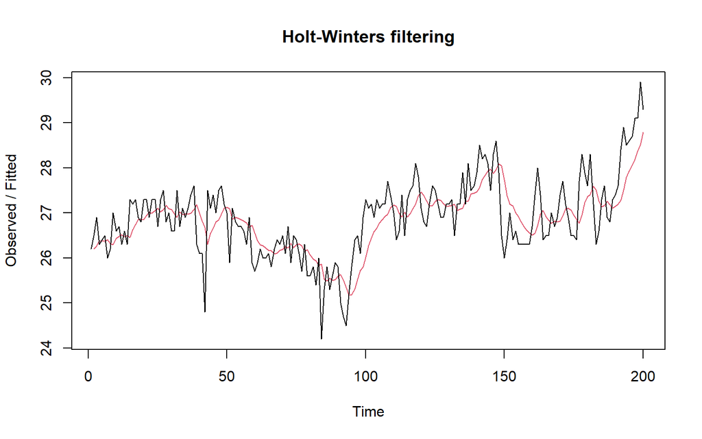

```r
ses1<- HoltWinters(train_ma.ts, gamma = FALSE, beta = FALSE, alpha = 0.2)
plot(ses1)
```

```r
#ramalan
ramalan1 <- forecast::forecast(ses1, h = 50)
ramalan1
```

```
##     Point Forecast    Lo 80    Hi 80    Lo 95    Hi 95
## 201       28.89443 28.13937 29.64949 27.73967 30.04919
## 202       28.89443 28.12442 29.66444 27.71680 30.07206
## 203       28.89443 28.10975 29.67911 27.69437 30.09449
## 204       28.89443 28.09535 29.69351 27.67235 30.11651
## 205       28.89443 28.08121 29.70765 27.65072 30.13814
## 206       28.89443 28.06731 29.72155 27.62945 30.15941
## 207       28.89443 28.05363 29.73523 27.60854 30.18032
## 208       28.89443 28.04018 29.74868 27.58797 30.20089
## 209       28.89443 28.02694 29.76192 27.56771 30.22115
## 210       28.89443 28.01389 29.77497 27.54776 30.24110
## 211       28.89443 28.00104 29.78783 27.52810 30.26076
## 212       28.89443 27.98836 29.80050 27.50872 30.28014
## 213       28.89443 27.97586 29.81300 27.48960 30.29926
## 214       28.89443 27.96353 29.82533 27.47075 30.31811
```

[output cut: 36 more lines]

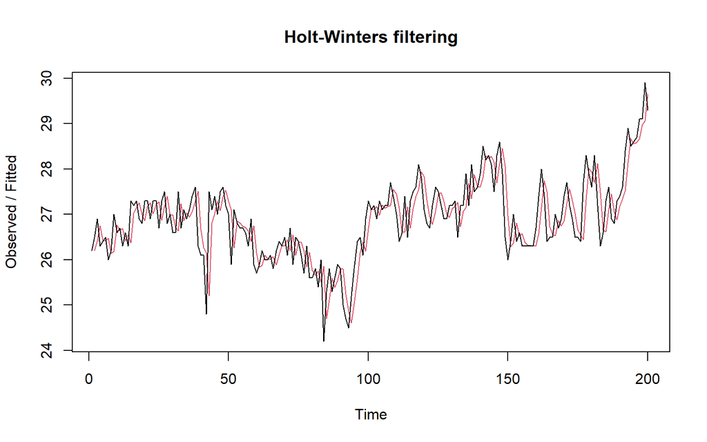

```r
ses2<- HoltWinters(train_ma.ts, gamma = FALSE, beta = FALSE, alpha = 0.7)
plot(ses2)
```

```r
#ramalan
ramalan2<- forecast::forecast(ses2, h=50)
ramalan2
```

```
##     Point Forecast    Lo 80    Hi 80    Lo 95    Hi 95
## 201       29.40448 28.72560 30.08336 28.36622 30.44274
## 202       29.40448 28.57580 30.23316 28.13713 30.67183
## 203       29.40448 28.44921 30.35975 27.94353 30.86544
## 204       29.40448 28.33754 30.47142 27.77273 31.03623
## 205       29.40448 28.23649 30.57247 27.61820 31.19077
## 206       29.40448 28.14352 30.66544 27.47601 31.33296
## 207       29.40448 28.05694 30.75202 27.34360 31.46536
## 208       29.40448 27.97561 30.83336 27.21920 31.58976
## 209       29.40448 27.89865 30.91031 27.10152 31.70745
## 210       29.40448 27.82545 30.98351 26.98956 31.81940
## 211       29.40448 27.75549 31.05347 26.88257 31.92640
## 212       29.40448 27.68838 31.12058 26.77993 32.02903
## 213       29.40448 27.62380 31.18517 26.68116 32.12780
## 214       29.40448 27.56148 31.24749 26.58585 32.22311
```

[output cut: 36 more lines]

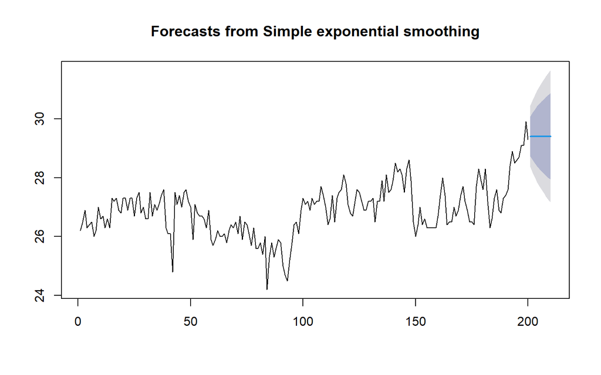

```r
#SES
ses.opt <- ses(train_ma.ts, h = 10, alpha = NULL)
plot(ses.opt)
```

```r
ses.opt
```

```
##     Point Forecast    Lo 80    Hi 80    Lo 95    Hi 95
## 201       29.40484 28.72623 30.08345 28.36700 30.44268
## 202       29.40484 28.59927 30.21040 28.17283 30.63684
## 203       29.40484 28.48976 30.31991 28.00535 30.80432
## 204       29.40484 28.39203 30.41765 27.85588 30.95380
## 205       29.40484 28.30292 30.50675 27.71961 31.09007
## 206       29.40484 28.22051 30.58917 27.59356 31.21612
## 207       29.40484 28.14346 30.66621 27.47573 31.33395
## 208       29.40484 28.07086 30.73882 27.36470 31.44498
## 209       29.40484 28.00201 30.80767 27.25940 31.55028
## 210       29.40484 27.93639 30.87329 27.15904 31.65064
```

```r
#Lamda Optimum Holt Winter
HWopt<- HoltWinters(train_ma.ts, gamma = FALSE, beta = FALSE,alpha = NULL)
HWopt
```

```
## Holt-Winters exponential smoothing without trend and without seasonal component.
##
## Call:
## HoltWinters(x = train_ma.ts, alpha = NULL, beta = FALSE, gamma = FALSE)
##
## Smoothing parameters:
##  alpha: 0.6413474
##  beta : FALSE
##  gamma: FALSE
##
## Coefficients:
##       [,1]
## a 29.40494
```

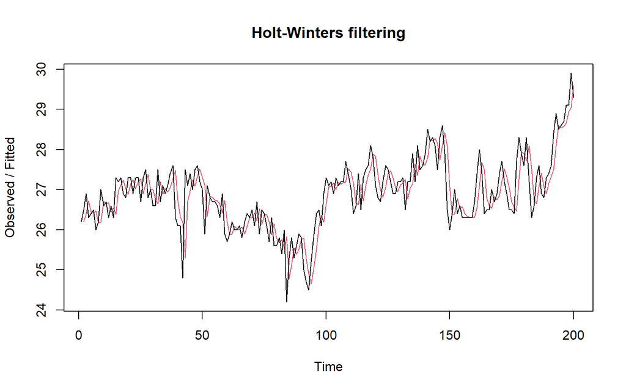

```r
plot(HWopt)
```

```r
ramalanopt<- forecast::forecast(HWopt, h=50)
ramalanopt
```

```
##     Point Forecast    Lo 80    Hi 80    Lo 95    Hi 95
## 201       29.40494 28.72698 30.08291 28.36808 30.44180
## 202       29.40494 28.59952 30.21036 28.17316 30.63672
## 203       29.40494 28.48965 30.32023 28.00513 30.80476
## 204       29.40494 28.39162 30.41826 27.85520 30.95468
## 205       29.40494 28.30227 30.50761 27.71856 31.09133
## 206       29.40494 28.21964 30.59024 27.59218 31.21770
## 207       29.40494 28.14241 30.66748 27.47406 31.33582
## 208       29.40494 28.06963 30.74025 27.36276 31.44712
## 209       29.40494 28.00062 30.80926 27.25722 31.55266
## 210       29.40494 27.93485 30.87504 27.15663 31.65326
## 211       29.40494 27.87189 30.93799 27.06035 31.74954
## 212       29.40494 27.81142 30.99846 26.96787 31.84202
## 213       29.40494 27.75317 31.05672 26.87877 31.93111
## 214       29.40494 27.69690 31.11299 26.79271 32.01717
```

[output cut: 36 more lines]

## 7.3 Akurasi Data Latih

```r
SSE1<-ses1$SSE
MSE1<-ses1$SSE/length(train_ma.ts)
RMSE1<-sqrt(MSE1)
MAPE1 <- mean(abs(ses.1$residuals/train_ma.ts))*100

akurasi1 <- matrix(c(SSE1,MSE1,RMSE1,MAPE1))
row.names(akurasi1)<- c("SSE", "MSE", "RMSE", "MAPE")
colnames(akurasi1) <- c("Akurasi lamda=0.2")
akurasi1
```

```
##      Akurasi lamda=0.2
## SSE         69.6429493
## MSE          0.3482147
## RMSE         0.5900972
## MAPE         1.7495453
```

```r
SSE2<-ses2$SSE
MSE2<-ses2$SSE/length(train_ma.ts)
RMSE2<-sqrt(MSE2)
MAPE2 <- mean(abs(ses.2$residuals/train_ma.ts))*100

akurasi2 <- matrix(c(SSE2,MSE2,RMSE2, MAPE2))
row.names(akurasi2)<- c("SSE", "MSE", "RMSE", "MAPE")
colnames(akurasi2) <- c("Akurasi lamda=0.7")
akurasi2
```

```
##      Akurasi lamda=0.7
## SSE         55.6673633
## MSE          0.2783368
## RMSE         0.5275764
## MAPE         1.5136975
```

## 7.4 Akurasi Data Uji

```r
n_test <- nrow(testing_ma)

e1   <- as.numeric(ramalan1$mean)[1:n_test] - as.numeric(testing_ma$temp_mean)
e2   <- as.numeric(ramalan2$mean)[1:n_test] - as.numeric(testing_ma$temp_mean)
eopt <- as.numeric(ramalanopt$mean)[1:n_test] - as.numeric(testing_ma$temp_mean)

SSEtesting1  <- sum(e1^2,  na.rm = TRUE)
MSEtesting1  <- mean(e1^2, na.rm = TRUE)
RMSEtesting1 <- sqrt(MSEtesting1)

SSEtesting2  <- sum(e2^2,  na.rm = TRUE)
MSEtesting2  <- mean(e2^2, na.rm = TRUE)
RMSEtesting2 <- sqrt(MSEtesting2)

SSEtestingopt  <- sum(eopt^2,  na.rm = TRUE)
MSEtestingopt  <- mean(eopt^2, na.rm = TRUE)
RMSEtestingopt <- sqrt(MSEtestingopt)

# Tabel ringkas
akurasitesting_SSE <- matrix(c(SSEtesting1, SSEtesting2, SSEtestingopt),
                             nrow = 3,
                             dimnames = list(c("SSE1","SSE2","SSEopt"), "Nilai"))
akurasitesting_MSE <- matrix(c(MSEtesting1, MSEtesting2, MSEtestingopt),
                             nrow = 3,
                             dimnames = list(c("MSE1","MSE2","MSEopt"), "Nilai"))
akurasitesting_RMSE <- matrix(c(RMSEtesting1, RMSEtesting2, RMSEtestingopt),
                              nrow = 3,
                              dimnames = list(c("RMSE1","RMSE2","RMSEopt"), "Nilai"))

akurasitesting_SSE
```

```
##           Nilai
## SSE1   378.1534
## SSE2   526.2445
## SSEopt 526.3897
```

```r
akurasitesting_MSE
```

```
##            Nilai
## MSE1    7.563067
## MSE2   10.524889
## MSEopt 10.527794
```

```r
akurasitesting_RMSE
```

```
##            Nilai
## RMSE1   2.750103
## RMSE2   3.244209
## RMSEopt 3.244656
```

```r
accuracy(ramalan1, testing_ma$temp_mean)
```

```
##                       ME     RMSE       MAE         MPE     MAPE     MASE
## Training set  0.06769926 0.591578 0.4732377   0.2023063  1.75846 1.122459
## Test set     -2.64843038 2.750103 2.6484304 -10.1776085 10.17761 6.281736
##                   ACF1
## Training set 0.4739566
## Test set            NA
```

```r
accuracy(ramalan2, testing_ma$temp_mean)
```

```
##                       ME      RMSE       MAE          MPE      MAPE      MASE
## Training set  0.02300417 0.5289003 0.4077883   0.05736254  1.519934 0.9672213
## Test set     -3.15848145 3.2442085 3.1584814 -12.12248872 12.122489 7.4915114
##                     ACF1
## Training set 0.001570027
## Test set              NA
```

```r
accuracy(ramalanopt, testing_ma$temp_mean)
```

```
##                       ME      RMSE       MAE          MPE      MAPE      MASE
## Training set  0.02511156 0.5282845 0.4075232   0.06387957  1.519023 0.9665926
## Test set     -3.15894129 3.2446562 3.1589413 -12.12424214 12.124242 7.4926021
##                    ACF1
## Training set 0.05108258
## Test set             NA
```

# 8 DOUBLE EXPONENTIAL SMOOTHING (DES)

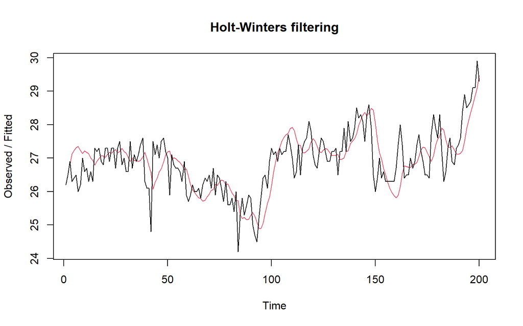

```r
des.1<- HoltWinters(train_ma.ts, gamma = FALSE, beta = 0.2, alpha = 0.2)
plot(des.1)
```

```r
ramalandes1<- forecast::forecast(des.1, h=50)
ramalandes1
```

```
##     Point Forecast    Lo 80    Hi 80    Lo 95    Hi 95
## 201       29.64438 28.81065 30.47811 28.36930 30.91946
## 202       29.85392 28.99652 30.71133 28.54264 31.16521
## 203       30.06347 29.17485 30.95208 28.70445 31.42249
## 204       30.27301 29.34521 31.20081 28.85406 31.69196
## 205       30.48255 29.50741 31.45769 28.99120 31.97390
## 206       30.69210 29.66150 31.72269 29.11594 32.26825
## 207       30.90164 29.80770 31.99557 29.22861 32.57467
## 208       31.11118 29.94634 32.27602 29.32972 32.89264
## 209       31.32072 30.07782 32.56362 29.41987 33.22158
## 210       31.53027 30.20257 32.85797 29.49973 33.56081
## 211       31.73981 30.32100 33.15862 29.56993 33.90969
## 212       31.94935 30.43352 33.46518 29.63109 34.26761
## 213       32.15889 30.54051 33.77727 29.68380 34.63399
## 214       32.36844 30.64232 34.09456 29.72856 35.00831
```

[output cut: 36 more lines]

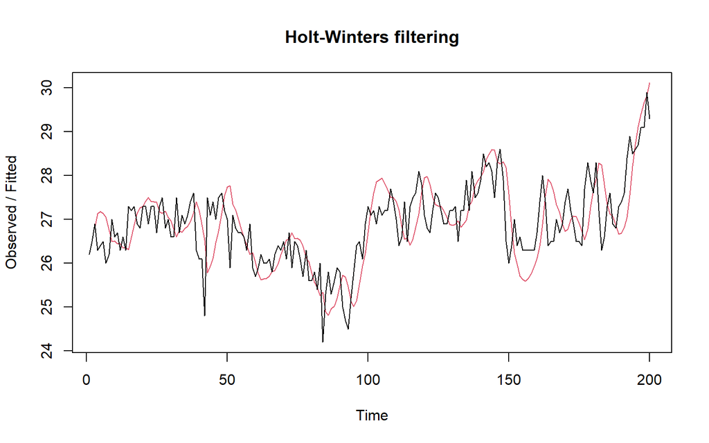

```r
des.2<- HoltWinters(train_ma.ts, gamma = FALSE, beta = 0.6, alpha = 0.2)
plot(des.2)
```

```r
ramalandes2<- forecast::forecast(des.2, h=50)
ramalandes2
```

```
##     Point Forecast    Lo 80    Hi 80     Lo 95    Hi 95
## 201       30.13042 29.25359 31.00726 28.789420 31.47143
## 202       30.30846 29.38782 31.22909 28.900467 31.71645
## 203       30.48649 29.48829 31.48470 28.959866 32.01312
## 204       30.66453 29.55209 31.77697 28.963194 32.36586
## 205       30.84256 29.58040 32.10472 28.912260 32.77286
## 206       31.02060 29.57661 32.46458 28.812209 33.22898
## 207       31.19863 29.54459 32.85267 28.668996 33.72826
## 208       31.37666 29.48790 33.26543 28.488052 34.26528
## 209       31.55470 29.40948 33.69992 28.273865 34.83553
## 210       31.73273 29.31165 34.15381 28.030006 35.43546
## 211       31.91077 29.19626 34.62528 27.759280 36.06225
## 212       32.08880 29.06475 35.11285 27.463910 36.71369
## 213       32.26683 28.91829 35.61538 27.145673 37.38800
## 214       32.44487 28.75782 36.13192 26.806013 38.08372
```

[output cut: 36 more lines]

## 8.1 Visualisasi Perbandingan Data latih dan Data Uji

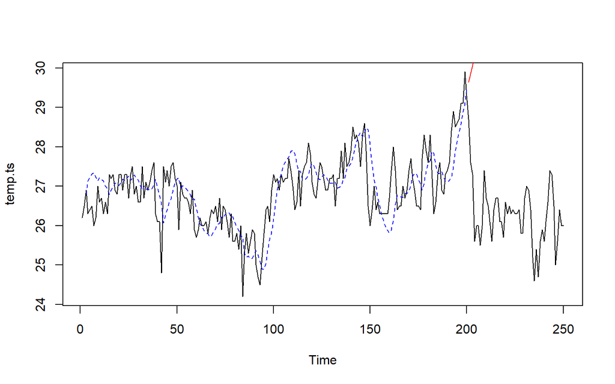

```r
plot(temp.ts)
lines(des.1$fitted[,1], lty=2, col="blue")
lines(ramalandes1$mean, col="red")
```

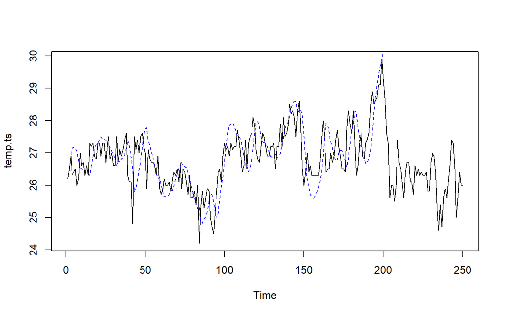

```r
plot(temp.ts)
lines(des.2$fitted[,1], lty=2, col="blue")
lines(ramalandes2$mean, col="red")
```

## 8.2 Lamda dan gamma optimum

```r
des.opt<- HoltWinters(train_ma.ts, gamma = FALSE)
des.opt
```

```
## Holt-Winters exponential smoothing with trend and without seasonal component.
##
## Call:
## HoltWinters(x = train_ma.ts, gamma = FALSE)
##
## Smoothing parameters:
##  alpha: 0.6970868
##  beta : 0.0470407
##  gamma: FALSE
##
## Coefficients:
##          [,1]
## a 29.44383818
## b  0.08227055
```

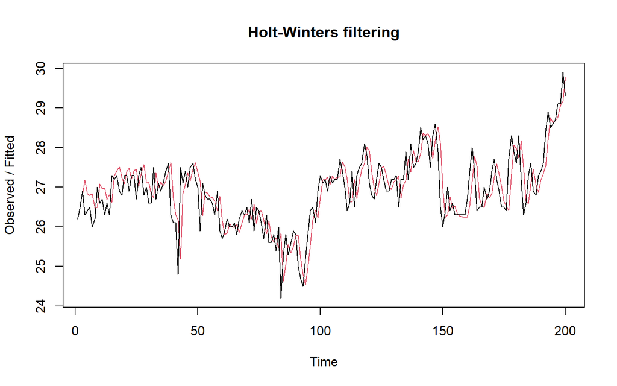

```r
plot(des.opt)
```

```r
ramalandesopt<- forecast::forecast(des.opt, h=50)
ramalandesopt
```

```
##     Point Forecast    Lo 80    Hi 80    Lo 95    Hi 95
## 201       29.52611 28.82372 30.22850 28.45189 30.60033
## 202       29.60838 28.73879 30.47796 28.27846 30.93830
## 203       29.69065 28.66930 30.71200 28.12864 31.25266
## 204       29.77292 28.60874 30.93710 27.99246 31.55338
## 205       29.85519 28.55374 31.15664 27.86480 31.84558
## 206       29.93746 28.50235 31.37257 27.74265 32.13227
## 207       30.01973 28.45330 31.58616 27.62408 32.41538
## 208       30.10200 28.40574 31.79827 27.50779 32.69622
## 209       30.18427 28.35905 32.00950 27.39283 32.97571
## 210       30.26654 28.31279 32.22029 27.27854 33.25455
## 211       30.34881 28.26663 32.43100 27.16439 33.53324
## 212       30.43108 28.22031 32.64186 27.05000 33.81217
## 213       30.51336 28.17363 32.85308 26.93506 34.09165
## 214       30.59563 28.12644 33.06481 26.81933 34.37192
```

[output cut: 36 more lines]

## 8.3 Akurasi Data Latih

```r
ssedes.train1<-des.1$SSE
msedes.train1<-ssedes.train1/length(train_ma.ts)
sisaandes1<-ramalandes1$residuals
head(sisaandes1)
```

```
## Time Series:
## Start = 1
## End = 6
## Frequency = 1
## [1]         NA         NA  0.1000000 -0.8240000 -0.8302400 -0.8020224
```

```r
mapedes.train1 <- sum(abs(sisaandes1[3:length(train_ma.ts)]/train_ma.ts[3:length(train_ma.ts)])
                      *100)/length(train_ma.ts)

akurasides.1 <- matrix(c(ssedes.train1,msedes.train1,mapedes.train1))
row.names(akurasides.1)<- c("SSE", "MSE", "MAPE")
colnames(akurasides.1) <- c("Akurasi lamda=0.2 dan gamma=0.2")
akurasides.1
```

```
##      Akurasi lamda=0.2 dan gamma=0.2
## SSE                       83.4024373
## MSE                        0.4170122
## MAPE                       1.8736476
```

```r
ssedes.train2<-des.2$SSE
msedes.train2<-ssedes.train2/length(train_ma.ts)
sisaandes2<-ramalandes2$residuals
head(sisaandes2)
```

```
## Time Series:
## Start = 1
## End = 6
## Frequency = 1
## [1]         NA         NA  0.1000000 -0.8320000 -0.7777600 -0.6410368
```

```r
mapedes.train2 <- sum(abs(sisaandes2[3:length(train_ma.ts)]/train_ma.ts[3:length(train_ma.ts)])
                      *100)/length(train_ma.ts)

akurasides.2 <- matrix(c(ssedes.train2,msedes.train2,mapedes.train2))
row.names(akurasides.2)<- c("SSE", "MSE", "MAPE")
colnames(akurasides.2) <- c("Akurasi lamda=0.2 dan gamma=0.6")
akurasides.2
```

```
##      Akurasi lamda=0.2 dan gamma=0.6
## SSE                       92.2263478
## MSE                        0.4611317
## MAPE                       2.0035355
```

## 8.4 Akurasi Data Uji

```r
selisihdes1<-ramalandes1$mean-testing_ma$temp_mean
selisihdes1
```

```
## Time Series:
## Start = 201
## End = 250
## Frequency = 1
##  [1]  0.9443809  2.2539237  2.7634666  4.6730094  4.4825522  4.6920951
##  [7]  5.4016379  5.1111807  3.9207236  4.8302664  5.2398092  5.8493520
## [13]  6.5588949  5.9684377  5.8779805  6.0875234  6.8970662  7.1066090
## [19]  7.7161519  7.0256947  7.5352375  7.5447804  7.9543232  8.0638660
## [25]  8.3734089  8.5829517  8.6924945  9.5020374  9.7115802  9.0211230
## [31]  8.9306658  9.2402087  9.9497515 11.3592943 12.1688372 11.5783800
## [37] 12.4879228 11.7974657 11.7070085 12.2165513 11.9260942 11.6356370
## [43] 11.0451798 11.3547227 12.3642655 14.0738083 13.6833512 13.0928940
## [49] 13.7024368 13.9119796
```

```r
SSEtestingdes1<-sum(selisihdes1^2)
MSEtestingdes1<-SSEtestingdes1/length(testing_ma$temp_mean)
MAPEtestingdes1<-sum(abs(selisihdes1/testing_ma$temp_mean)*100)/length(testing_ma$temp_mean)

selisihdes2<-ramalandes2$mean-testing_ma$temp_mean
selisihdes2
```

```
## Time Series:
## Start = 201
## End = 250
## Frequency = 1
##  [1]  1.430424  2.708458  3.186492  5.064527  4.842561  5.020595  5.698629
##  [8]  5.376664  4.154698  5.032732  5.410766  5.988801  6.666835  6.044869
## [15]  5.922903  6.100938  6.878972  7.057006  7.635040  6.913075  7.391109
## [22]  7.369143  7.747177  7.825211  8.103246  8.281280  8.359314  9.137348
## [29]  9.315383  8.593417  8.471451  8.749485  9.427520 10.805554 11.583588
## [36] 10.961622 11.839657 11.117691 10.995725 11.473759 11.151794 10.829828
## [43] 10.207862 10.485896 11.463931 13.141965 12.719999 12.098033 12.676068
## [50] 12.854102
```

```r
SSEtestingdes2<-sum(selisihdes2^2)
MSEtestingdes2<-SSEtestingdes2/length(testing_ma$temp_mean)
MAPEtestingdes2<-sum(abs(selisihdes2/testing_ma$temp_mean)*100)/length(testing_ma$temp_mean)

selisihdesopt<-ramalandesopt$mean-testing_ma$temp_mean
selisihdesopt
```

```
## Time Series:
## Start = 201
## End = 250
## Frequency = 1
##  [1] 0.8261087 2.0083793 2.3906498 4.1729204 3.8551909 3.9374615 4.5197320
##  [8] 4.1020025 2.7842731 3.5665436 3.8488142 4.3310847 4.9133553 4.1956258
## [15] 3.9778964 4.0601669 4.7424375 4.8247080 5.3069785 4.4892491 4.8715196
## [22] 4.7537902 5.0360607 5.0183313 5.2006018 5.2828724 5.2651429 5.9474135
## [29] 6.0296840 5.2119545 4.9942251 5.1764956 5.7587662 7.0410367 7.7233073
## [36] 7.0055778 7.7878484 6.9701189 6.7523894 7.1346600 6.7169305 6.2992011
## [43] 5.5814716 5.7637422 6.6460127 8.2282833 7.7105538 6.9928244 7.4750949
## [50] 7.5573654
```

```r
SSEtestingdesopt<-sum(selisihdesopt^2)
MSEtestingdesopt<-SSEtestingdesopt/length(testing_ma$temp_mean)
MAPEtestingdesopt<-sum(abs(selisihdesopt/testing_ma$temp_mean)*100)/length(testing_ma$temp_mean)

akurasitestingdes <-
  matrix(c(SSEtestingdes1,MSEtestingdes1,MAPEtestingdes1,SSEtestingdes2,MSEtestingdes2,
           MAPEtestingdes2,SSEtestingdesopt,MSEtestingdesopt,MAPEtestingdesopt),
         nrow=3,ncol=3)
row.names(akurasitestingdes)<- c("SSE", "MSE", "MAPE")
colnames(akurasitestingdes) <- c("des ske1","des ske2","des opt")
akurasitestingdes
```

```
##        des ske1   des ske2    des opt
## SSE  4193.96486 3816.50610 1527.41841
## MSE    83.87930   76.33012   30.54837
## MAPE   32.71204   31.60691   20.31097
```

# 9 METODE PERAMALAN TERBAIK

```r
library(knitr)
library(kableExtra)
```

```r
evaluasi <- data.frame(
  Model = c("SMA", "DMA", "SES($\\alpha=0.2$)", "DES($\\alpha=0.69$, $\\beta=0.04$ )"),
  SSE   = c(535.3988, 3534.6996, 378.1534, 1527.4184),
  MSE   = c(10.7079, 70.6939, 7.5630, 30.5483),
  MAPE  = c(12.2325, 30.2805, 10.1776, 20.3109)
)

kable(
  evaluasi,
  caption = "Matriks Evaluasi Data Uji pada 4 Model",
  escape = FALSE,
  digits = 4
) %>%
  kable_styling(full_width = FALSE,
                bootstrap_options = c("striped", "hover", "condensed")) %>%
  column_spec(1, bold = TRUE) %>%
  row_spec(0, bold = TRUE, background = "#f2f2f2")
```

Matriks Evaluasi Data Uji pada 4 Model

| Model | SSE | MSE | MAPE |
| --- | --- | --- | --- |
| SMA | 535.3988 | 10.7079 | 12.2325 |
| DMA | 3534.6996 | 70.6939 | 30.2805 |
| SES($\alpha=0.2$) | 378.1534 | 7.5630 | 10.1776 |
| DES($\alpha=0.69$, $\beta=0.04$ ) | 1527.4184 | 30.5483 | 20.3109 |

## 9.1 Kesimpulan

Evaluasi akhir saya lakukan hanya pada data uji karena data inilah yang merepresentasikan kemampuan model dalam melakukan generalisasi terhadap data baru yang tidak digunakan pada proses pelatihan, sehingga lebih mencerminkan kinerja model yang sesungguhnya.

Berdasarkan hasil evaluasi terhadap empat model peramalan, yaitu Simple Moving Average (SMA), Double Moving Average (DMA), Single Exponential Smoothing (SES), dan Double Exponential Smoothing (DES), diperoleh bahwa model SES dengan parameter α = 0.2 merupakan model dengan performa terbaik. Hal ini ditunjukkan oleh nilai Sum of Squared Error (SSE), Mean Squared Error (MSE), dan Mean Absolute Percentage Error (MAPE) yang paling rendah dibandingkan dengan model lainnya, masing-masing sebesar 378.1534, 7.5630, dan 10.1776. Dengan tingkat kesalahan relatif sekitar 10.18%, model SES dapat dikatakan memiliki kemampuan prediksi yang paling mendekati data aktual. Sementara itu, model DMA menunjukkan kinerja terburuk dengan nilai error yang relatif tinggi.**Oleh karena itu, dapat disimpulkan bahwa model SES dengan α = 0.2 merupakan metode peramalan yang paling sesuai untuk digunakan dalam penelitian ini.**